# DA5030 Practice Problems 1

Jiaming Xu

25 January 2022

```r
df <- read_csv('https://da5030.weebly.com/uploads/8/6/5/9/8659576/customertxndata.csv', col_names = F)
colnames(df) <- c("nvis", "ntrans", "os", "gender", "revenue")
df
```

| nvis | ntrans | os | gender | revenue |
| --- | --- | --- | --- | --- |
| 7 | 0 | Android | Male | 0.0000 |
| 20 | 1 | iOS | NA | 576.8668 |
| 22 | 1 | iOS | Female | 850.0000 |
| 24 | 2 | iOS | Female | 1050.0000 |
| 1 | 0 | Android | Male | 0.0000 |
| 13 | 1 | Android | Male | 460.0000 |
| 23 | 2 | iOS | Male | 1850.0000 |
| 14 | 1 | Android | Male | 480.0000 |
| 11 | 1 | Android | Male | 110.0000 |
| 24 | 2 | iOS | Male | 1950.0000 |

[output cut: 990 more lines]

```r
summarise(df,
          total_revenue = sum(revenue, na.rm=T),
          mean_nvis = mean(nvis, na.rm=T),
          med_revenue = median(revenue, na.rm = T),
          sd_revenue = sd(revenue, na.rm = T),
          com_gender = names(sort(table(df$gender), decreasing=T))[1])
```

| total_revenue | mean_nvis | med_revenue | sd_revenue | com_gender |
| --- | --- | --- | --- | --- |
| 10372524 | 12.48649 | 344.6516 | 425.9884 | Male |

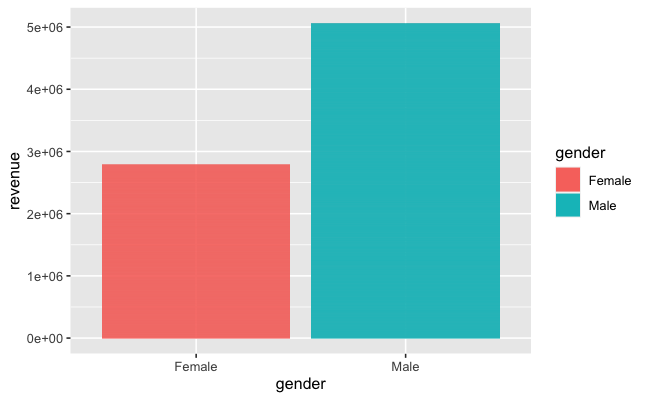

```r
df %>%
    select(gender, revenue) %>%
    drop_na() %>%
    ggplot() +
        geom_bar(mapping = aes( x = gender, y = revenue, fill = gender), stat = 'identity')
```

Correlation between number of visits and customer costs is 0.739. This indicate a strong relationship between two variables.

```r
cor(df$nvis, df$revenue, method = "pearson", use = "pairwise.complete.obs")
```

```
[1] 0.7388448
```

number of transactions and gender variables contain missing data. It’s hard to infer missing data from other information since we have so few variables available. Therefore, I use the statistical value replacing the missing values. However, it’s impossible to use statistical for gender since it’s a categorical data, and I only apply this replacement to transactions. I use “sapply” function to apply “sum(is.na( ))” function to columns in df to calculate number of missing values in each column.

```r
sapply(df, function(x) sum(is.na(x)))
```

```
   nvis  ntrans      os  gender revenue
      0    1800       0    5400       0
```

As the result in question 3, male is the mode of gender. It’s easier to manually replace them since only two columns and they’re different type of replacement.

```r
df$ntrans[is.na(df$ntrans)] <- round(mean(df$ntrans, na.rm = T), digits = 0)
df$gender[is.na(df$gender)] <- "male"
```

generate a sequence same length as df, then turn it to 0 and 1s. Odd for 1 and even for 0.

```r
split_index <- seq(1, nrow(df)) %% 2
train_df <- df[split_index == 1, ]
valid_df <- df[split_index == 0, ]
```

```r
print( sprintf( "Average revenue of train dataset: $%.2f, validation dataset: $%.2f. ",
                mean(train_df$revenue), mean(valid_df$revenue)))
```

```
[1] "Average revenue of train dataset: $449.61, validation dataset: $460.26. "
```

```r
set.seed(77654)
sample <- sample(1:3,size=nrow(df),replace=TRUE,prob=c(0.6,0.2,0.2))
train <- df[sample == 1, ]
valid <- df[sample == 2, ]
test <- df[sample == 3, ]
```